# examples_0415

Evaluate the expression below.

$$7\cdot 10^{3}+5\cdot 10^{2}+2\cdot
10^{1}+1\cdot 10^{0}$$

This is easier than it looks.

$$7\cdot 10^{3}+5\cdot 10^{2}+2\cdot
10^{1}+1\cdot 10^{0}$$

$$7\cdot 1000+5\cdot 100+2\cdot 10+1\cdot
1$$

$$7000+500+20+1$$

$$7521$$

Evaluate the expression below.

$$5\cdot 10^{3}+9\cdot 10^{2}+3\cdot
10^{1}+7\cdot 10^{0}$$

This is easier than it looks.

$$5\cdot 10^{3}+9\cdot 10^{2}+3\cdot
10^{1}+7\cdot 10^{0}$$

$$5\cdot 1000+9\cdot 100+3\cdot 10+7\cdot
1$$

$$5000+900+30+7$$

$$5937$$

Evaluate the expression below.

$$3\cdot 10^{3}+1\cdot 10^{2}+8\cdot
10^{1}+7\cdot 10^{0}$$

This is easier than it looks.

$$3\cdot 10^{3}+1\cdot 10^{2}+8\cdot
10^{1}+7\cdot 10^{0}$$

$$3\cdot 1000+1\cdot 100+8\cdot 10+7\cdot
1$$

$$3000+100+80+7$$

$$3187$$

Evaluate the expression below.

$$7\cdot 10^{4}+3\cdot 10^{3}+8\cdot
10^{2}+2\cdot 10^{1}+9\cdot 10^{0}$$

This is easier than it looks.

$$7\cdot 10^{4}+3\cdot 10^{3}+8\cdot
10^{2}+2\cdot 10^{1}+9\cdot 10^{0}$$

$$7\cdot 10000+3\cdot 1000+8\cdot
100+2\cdot 10+9\cdot 1$$

$$70000+3000+800+20+9$$

$$73829$$

Evaluate the expression below.

$$1\cdot 10^{3}+6\cdot 10^{2}+2\cdot
10^{1}+7\cdot 10^{0}$$

This is easier than it looks.

$$1\cdot 10^{3}+6\cdot 10^{2}+2\cdot
10^{1}+7\cdot 10^{0}$$

$$1\cdot 1000+6\cdot 100+2\cdot 10+7\cdot
1$$

$$1000+600+20+7$$

$$1627$$

Evaluate the expression below.

$$3\cdot 10^{4}+9\cdot 10^{3}+7\cdot
10^{2}+5\cdot 10^{1}+8\cdot 10^{0}$$

This is easier than it looks.

$$3\cdot 10^{4}+9\cdot 10^{3}+7\cdot
10^{2}+5\cdot 10^{1}+8\cdot 10^{0}$$

$$3\cdot 10000+9\cdot 1000+7\cdot
100+5\cdot 10+8\cdot 1$$

$$30000+9000+700+50+8$$

$$39758$$

Evaluate the expression below.

$$1\cdot 10^{4}+2\cdot 10^{3}+4\cdot
10^{2}+7\cdot 10^{1}+3\cdot 10^{0}$$

This is easier than it looks.

$$1\cdot 10^{4}+2\cdot 10^{3}+4\cdot
10^{2}+7\cdot 10^{1}+3\cdot 10^{0}$$

$$1\cdot 10000+2\cdot 1000+4\cdot
100+7\cdot 10+3\cdot 1$$

$$10000+2000+400+70+3$$

$$12473$$

Evaluate the expression below.

$$2\cdot 10^{3}+3\cdot 10^{2}+5\cdot
10^{1}+6\cdot 10^{0}$$

This is easier than it looks.

$$2\cdot 10^{3}+3\cdot 10^{2}+5\cdot
10^{1}+6\cdot 10^{0}$$

$$2\cdot 1000+3\cdot 100+5\cdot 10+6\cdot
1$$

$$2000+300+50+6$$

$$2356$$

Evaluate the expression below.

$$3\cdot 10^{4}+6\cdot 10^{3}+2\cdot
10^{2}+1\cdot 10^{1}+5\cdot 10^{0}$$

This is easier than it looks.

$$3\cdot 10^{4}+6\cdot 10^{3}+2\cdot
10^{2}+1\cdot 10^{1}+5\cdot 10^{0}$$

$$3\cdot 10000+6\cdot 1000+2\cdot
100+1\cdot 10+5\cdot 1$$

$$30000+6000+200+10+5$$

$$36215$$

Evaluate the expression below.

$$8\cdot 10^{3}+9\cdot 10^{2}+7\cdot
10^{1}+5\cdot 10^{0}$$

This is easier than it looks.

$$8\cdot 10^{3}+9\cdot 10^{2}+7\cdot
10^{1}+5\cdot 10^{0}$$

$$8\cdot 1000+9\cdot 100+7\cdot 10+5\cdot
1$$

$$8000+900+70+5$$

$$8975$$

Evaluate the expression below.

$$3\cdot 10^{4}+5\cdot 10^{3}+2\cdot
10^{2}+7\cdot 10^{1}+9\cdot 10^{0}$$

This is easier than it looks.

$$3\cdot 10^{4}+5\cdot 10^{3}+2\cdot
10^{2}+7\cdot 10^{1}+9\cdot 10^{0}$$

$$3\cdot 10000+5\cdot 1000+2\cdot
100+7\cdot 10+9\cdot 1$$

$$30000+5000+200+70+9$$

$$35279$$

Evaluate the expression below.

$$1\cdot 10^{3}+3\cdot 10^{2}+2\cdot
10^{1}+5\cdot 10^{0}$$

This is easier than it looks.

$$1\cdot 10^{3}+3\cdot 10^{2}+2\cdot
10^{1}+5\cdot 10^{0}$$

$$1\cdot 1000+3\cdot 100+2\cdot 10+5\cdot
1$$

$$1000+300+20+5$$

$$1325$$

Evaluate the expression below.

$$2\cdot 10^{3}+6\cdot 10^{2}+1\cdot
10^{1}+7\cdot 10^{0}$$

This is easier than it looks.

$$2\cdot 10^{3}+6\cdot 10^{2}+1\cdot
10^{1}+7\cdot 10^{0}$$

$$2\cdot 1000+6\cdot 100+1\cdot 10+7\cdot
1$$

$$2000+600+10+7$$

$$2617$$

Evaluate the expression below.

$$4\cdot 10^{4}+3\cdot 10^{3}+2\cdot
10^{2}+8\cdot 10^{1}+7\cdot 10^{0}$$

This is easier than it looks.

$$4\cdot 10^{4}+3\cdot 10^{3}+2\cdot
10^{2}+8\cdot 10^{1}+7\cdot 10^{0}$$

$$4\cdot 10000+3\cdot 1000+2\cdot
100+8\cdot 10+7\cdot 1$$

$$40000+3000+200+80+7$$

$$43287$$

Evaluate the expression below.

$$6\cdot 10^{3}+3\cdot 10^{2}+8\cdot
10^{1}+5\cdot 10^{0}$$

This is easier than it looks.

$$6\cdot 10^{3}+3\cdot 10^{2}+8\cdot
10^{1}+5\cdot 10^{0}$$

$$6\cdot 1000+3\cdot 100+8\cdot 10+5\cdot
1$$

$$6000+300+80+5$$

$$6385$$

Evaluate the expression below.

$$9\cdot 10^{4}+5\cdot 10^{3}+7\cdot
10^{2}+8\cdot 10^{1}+3\cdot 10^{0}$$

This is easier than it looks.

$$9\cdot 10^{4}+5\cdot 10^{3}+7\cdot
10^{2}+8\cdot 10^{1}+3\cdot 10^{0}$$

$$9\cdot 10000+5\cdot 1000+7\cdot
100+8\cdot 10+3\cdot 1$$

$$90000+5000+700+80+3$$

$$95783$$

Evaluate the expression below.

$$3\cdot 10^{3}+1\cdot 10^{2}+8\cdot
10^{1}+7\cdot 10^{0}$$

This is easier than it looks.

$$3\cdot 10^{3}+1\cdot 10^{2}+8\cdot
10^{1}+7\cdot 10^{0}$$

$$3\cdot 1000+1\cdot 100+8\cdot 10+7\cdot
1$$

$$3000+100+80+7$$

$$3187$$

Evaluate the expression below.

$$1\cdot 10^{4}+7\cdot 10^{3}+5\cdot
10^{2}+6\cdot 10^{1}+3\cdot 10^{0}$$

This is easier than it looks.

$$1\cdot 10^{4}+7\cdot 10^{3}+5\cdot
10^{2}+6\cdot 10^{1}+3\cdot 10^{0}$$

$$1\cdot 10000+7\cdot 1000+5\cdot
100+6\cdot 10+3\cdot 1$$

$$10000+7000+500+60+3$$

$$17563$$

Evaluate the expression below.

$$6\cdot 10^{3}+7\cdot 10^{2}+9\cdot
10^{1}+2\cdot 10^{0}$$

This is easier than it looks.

$$6\cdot 10^{3}+7\cdot 10^{2}+9\cdot
10^{1}+2\cdot 10^{0}$$

$$6\cdot 1000+7\cdot 100+9\cdot 10+2\cdot
1$$

$$6000+700+90+2$$

$$6792$$

Evaluate the expression below.

$$1\cdot 10^{3}+5\cdot 10^{2}+2\cdot
10^{1}+4\cdot 10^{0}$$

This is easier than it looks.

$$1\cdot 10^{3}+5\cdot 10^{2}+2\cdot
10^{1}+4\cdot 10^{0}$$

$$1\cdot 1000+5\cdot 100+2\cdot 10+4\cdot
1$$

$$1000+500+20+4$$

$$1524$$

As an alien-human translator, you run into this alien number:

[figure not shown]

What number is represented (expressed in our base-10 human way)?

Each symbol represents a number between 0 and 3. Each position represents a power of 4. The total value is found by adding up the products of each symbol's value times its corresponding power of 4.

$$3\cdot 4^{4}+2\cdot 4^{3}+1\cdot
4^{2}+0\cdot 4^{1}+3\cdot 4^{0}$$

You should get the answer:

$$915$$

As an alien-human translator, you run into this alien number:

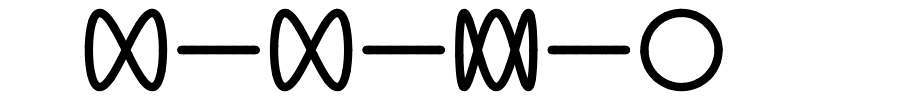

What number is represented (expressed in our base-10 human way)?

Each symbol represents a number between 0 and 3. Each position represents a power of 4. The total value is found by adding up the products of each symbol's value times its corresponding power of 4.

$$2\cdot 4^{6}+0\cdot 4^{5}+2\cdot
4^{4}+0\cdot 4^{3}+3\cdot 4^{2}+0\cdot 4^{1}+1\cdot 4^{0}$$

You should get the answer:

$$8753$$

As an alien-human translator, you run into this alien number:

[figure not shown]

What number is represented (expressed in our base-10 human way)?

Each symbol represents a number between 0 and 3. Each position represents a power of 4. The total value is found by adding up the products of each symbol's value times its corresponding power of 4.

$$3\cdot 4^{5}+2\cdot 4^{4}+1\cdot
4^{3}+1\cdot 4^{2}+0\cdot 4^{1}+1\cdot 4^{0}$$

You should get the answer:

$$3665$$

As an alien-human translator, you run into this alien number:

[figure not shown]

What number is represented (expressed in our base-10 human way)?

Each symbol represents a number between 0 and 3. Each position represents a power of 4. The total value is found by adding up the products of each symbol's value times its corresponding power of 4.

$$3\cdot 4^{5}+1\cdot 4^{4}+2\cdot
4^{3}+0\cdot 4^{2}+3\cdot 4^{1}+2\cdot 4^{0}$$

You should get the answer:

$$3470$$

As an alien-human translator, you run into this alien number:

[figure not shown]

What number is represented (expressed in our base-10 human way)?

Each symbol represents a number between 0 and 3. Each position represents a power of 4. The total value is found by adding up the products of each symbol's value times its corresponding power of 4.

$$2\cdot 4^{5}+3\cdot 4^{4}+0\cdot
4^{3}+3\cdot 4^{2}+3\cdot 4^{1}+1\cdot 4^{0}$$

You should get the answer:

$$2877$$

As an alien-human translator, you run into this alien number:

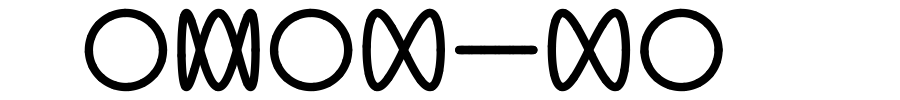

What number is represented (expressed in our base-10 human way)?

Each symbol represents a number between 0 and 3. Each position represents a power of 4. The total value is found by adding up the products of each symbol's value times its corresponding power of 4.

$$1\cdot 4^{6}+3\cdot 4^{5}+1\cdot
4^{4}+2\cdot 4^{3}+0\cdot 4^{2}+2\cdot 4^{1}+1\cdot 4^{0}$$

You should get the answer:

$$7561$$

As an alien-human translator, you run into this alien number:

[figure not shown]

What number is represented (expressed in our base-10 human way)?

Each symbol represents a number between 0 and 3. Each position represents a power of 4. The total value is found by adding up the products of each symbol's value times its corresponding power of 4.

$$2\cdot 4^{5}+0\cdot 4^{4}+3\cdot
4^{3}+1\cdot 4^{2}+1\cdot 4^{1}+2\cdot 4^{0}$$

You should get the answer:

$$2262$$

As an alien-human translator, you run into this alien number:

[figure not shown]

What number is represented (expressed in our base-10 human way)?

Each symbol represents a number between 0 and 3. Each position represents a power of 4. The total value is found by adding up the products of each symbol's value times its corresponding power of 4.

$$3\cdot 4^{6}+0\cdot 4^{5}+1\cdot
4^{4}+3\cdot 4^{3}+2\cdot 4^{2}+0\cdot 4^{1}+2\cdot 4^{0}$$

You should get the answer:

$$12770$$

As an alien-human translator, you run into this alien number:

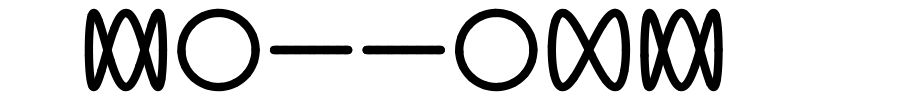

What number is represented (expressed in our base-10 human way)?

Each symbol represents a number between 0 and 3. Each position represents a power of 4. The total value is found by adding up the products of each symbol's value times its corresponding power of 4.

$$3\cdot 4^{6}+1\cdot 4^{5}+0\cdot
4^{4}+0\cdot 4^{3}+1\cdot 4^{2}+2\cdot 4^{1}+3\cdot 4^{0}$$

You should get the answer:

$$13339$$

As an alien-human translator, you run into this alien number:

[figure not shown]

What number is represented (expressed in our base-10 human way)?

Each symbol represents a number between 0 and 3. Each position represents a power of 4. The total value is found by adding up the products of each symbol's value times its corresponding power of 4.

$$2\cdot 4^{6}+2\cdot 4^{5}+0\cdot
4^{4}+1\cdot 4^{3}+3\cdot 4^{2}+3\cdot 4^{1}+1\cdot 4^{0}$$

You should get the answer:

$$10365$$

As an alien-human translator, you run into this alien number:

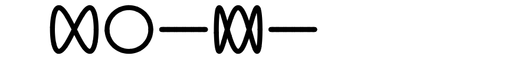

What number is represented (expressed in our base-10 human way)?

Each symbol represents a number between 0 and 3. Each position represents a power of 4. The total value is found by adding up the products of each symbol's value times its corresponding power of 4.

$$2\cdot 4^{4}+1\cdot 4^{3}+0\cdot
4^{2}+3\cdot 4^{1}+0\cdot 4^{0}$$

You should get the answer:

$$588$$

As an alien-human translator, you run into this alien number:

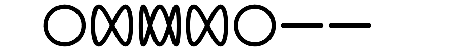

What number is represented (expressed in our base-10 human way)?

Each symbol represents a number between 0 and 3. Each position represents a power of 4. The total value is found by adding up the products of each symbol's value times its corresponding power of 4.

$$1\cdot 4^{6}+2\cdot 4^{5}+3\cdot
4^{4}+2\cdot 4^{3}+1\cdot 4^{2}+0\cdot 4^{1}+0\cdot 4^{0}$$

You should get the answer:

$$7056$$

As an alien-human translator, you run into this alien number:

[figure not shown]

What number is represented (expressed in our base-10 human way)?

Each symbol represents a number between 0 and 3. Each position represents a power of 4. The total value is found by adding up the products of each symbol's value times its corresponding power of 4.

$$3\cdot 4^{6}+3\cdot 4^{5}+1\cdot
4^{4}+1\cdot 4^{3}+0\cdot 4^{2}+1\cdot 4^{1}+2\cdot 4^{0}$$

You should get the answer:

$$15686$$

As an alien-human translator, you run into this alien number:

[figure not shown]

What number is represented (expressed in our base-10 human way)?

Each symbol represents a number between 0 and 3. Each position represents a power of 4. The total value is found by adding up the products of each symbol's value times its corresponding power of 4.

$$2\cdot 4^{5}+1\cdot 4^{4}+3\cdot
4^{3}+0\cdot 4^{2}+1\cdot 4^{1}+3\cdot 4^{0}$$

You should get the answer:

$$2503$$

As an alien-human translator, you run into this alien number:

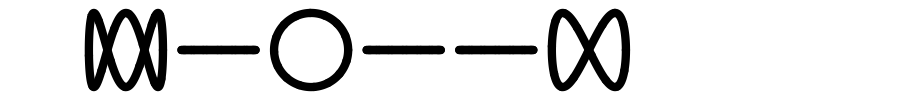

What number is represented (expressed in our base-10 human way)?

Each symbol represents a number between 0 and 3. Each position represents a power of 4. The total value is found by adding up the products of each symbol's value times its corresponding power of 4.

$$3\cdot 4^{5}+0\cdot 4^{4}+1\cdot
4^{3}+0\cdot 4^{2}+0\cdot 4^{1}+2\cdot 4^{0}$$

You should get the answer:

$$3138$$

As an alien-human translator, you run into this alien number:

[figure not shown]

What number is represented (expressed in our base-10 human way)?

Each symbol represents a number between 0 and 3. Each position represents a power of 4. The total value is found by adding up the products of each symbol's value times its corresponding power of 4.

$$3\cdot 4^{5}+0\cdot 4^{4}+0\cdot
4^{3}+3\cdot 4^{2}+2\cdot 4^{1}+1\cdot 4^{0}$$

You should get the answer:

$$3129$$

As an alien-human translator, you run into this alien number:

[figure not shown]

What number is represented (expressed in our base-10 human way)?

Each symbol represents a number between 0 and 3. Each position represents a power of 4. The total value is found by adding up the products of each symbol's value times its corresponding power of 4.

$$3\cdot 4^{5}+2\cdot 4^{4}+2\cdot
4^{3}+0\cdot 4^{2}+1\cdot 4^{1}+1\cdot 4^{0}$$

You should get the answer:

$$3717$$

As an alien-human translator, you run into this alien number:

[figure not shown]

What number is represented (expressed in our base-10 human way)?

Each symbol represents a number between 0 and 3. Each position represents a power of 4. The total value is found by adding up the products of each symbol's value times its corresponding power of 4.

$$2\cdot 4^{5}+3\cdot 4^{4}+0\cdot
4^{3}+1\cdot 4^{2}+0\cdot 4^{1}+2\cdot 4^{0}$$

You should get the answer:

$$2834$$

As an alien-human translator, you run into this alien number:

[figure not shown]

What number is represented (expressed in our base-10 human way)?

Each symbol represents a number between 0 and 3. Each position represents a power of 4. The total value is found by adding up the products of each symbol's value times its corresponding power of 4.

$$3\cdot 4^{4}+0\cdot 4^{3}+1\cdot
4^{2}+2\cdot 4^{1}+2\cdot 4^{0}$$

You should get the answer:

$$794$$

As an alien-human translator, you run into this alien number:

[figure not shown]

What number is represented (expressed in our base-10 human way)?

Each symbol represents a number between 0 and 3. Each position represents a power of 4. The total value is found by adding up the products of each symbol's value times its corresponding power of 4.

$$3\cdot 4^{4}+2\cdot 4^{3}+2\cdot
4^{2}+0\cdot 4^{1}+1\cdot 4^{0}$$

You should get the answer:

$$929$$

Consider an alien society that uses base-8 number system with the following symbols:

| Human number | Alien numeral |
| --- | --- |
| 0 | 0 |
| 1 | A |
| 2 | B |
| 3 | C |
| 4 | D |
| 5 | E |
| 6 | F |
| 7 | G |

Notice, the alien 0 is the same as our 0, but then they use uppercase letters in the order of our alphabet instead of Arabic numerals.

A human wants to convert the number 410 to Alien. Do this for them.

Divide 410 by the base 8 to get a quotient and remainder.
$$\frac{410}{8}~=~51+\frac{2}{8}$$

(The quotient was 51 and the remainder was 2.)

Divide 51 by the base 8 to get a quotient and remainder.
$$\frac{51}{8}~=~6+\frac{3}{8}$$

(The quotient was 6 and the remainder was 3.)

Divide 6 by the base 8 to get a quotient and remainder.
$$\frac{6}{8}~=~0+\frac{6}{8}$$

(The quotient was 0 and the remainder was 6.)

Now, write down the remainders in reverse order.

$$\text{remainders}~=~6, 3, 2$$

And, lastly, use the table to convert those amounts into alien symbols.

The answer: `FCB`

Consider an alien society that uses base-4 number system with the following symbols:

| Human number | Alien numeral |
| --- | --- |
| 0 | 0 |
| 1 | A |
| 2 | B |
| 3 | C |

Notice, the alien 0 is the same as our 0, but then they use uppercase letters in the order of our alphabet instead of Arabic numerals.

A human wants to convert the number 123 to Alien. Do this for them.

Divide 123 by the base 4 to get a quotient and remainder.
$$\frac{123}{4}~=~30+\frac{3}{4}$$

(The quotient was 30 and the remainder was 3.)

Divide 30 by the base 4 to get a quotient and remainder.
$$\frac{30}{4}~=~7+\frac{2}{4}$$

(The quotient was 7 and the remainder was 2.)

Divide 7 by the base 4 to get a quotient and remainder.
$$\frac{7}{4}~=~1+\frac{3}{4}$$

(The quotient was 1 and the remainder was 3.)

Divide 1 by the base 4 to get a quotient and remainder.
$$\frac{1}{4}~=~0+\frac{1}{4}$$

(The quotient was 0 and the remainder was 1.)

Now, write down the remainders in reverse order.

$$\text{remainders}~=~1, 3, 2,
3$$

And, lastly, use the table to convert those amounts into alien symbols.

The answer: `ACBC`

Consider an alien society that uses base-7 number system with the following symbols:

| Human number | Alien numeral |
| --- | --- |
| 0 | 0 |
| 1 | A |
| 2 | B |
| 3 | C |
| 4 | D |
| 5 | E |
| 6 | F |

Notice, the alien 0 is the same as our 0, but then they use uppercase letters in the order of our alphabet instead of Arabic numerals.

A human wants to convert the number 425 to Alien. Do this for them.

Divide 425 by the base 7 to get a quotient and remainder.
$$\frac{425}{7}~=~60+\frac{5}{7}$$

(The quotient was 60 and the remainder was 5.)

Divide 60 by the base 7 to get a quotient and remainder.
$$\frac{60}{7}~=~8+\frac{4}{7}$$

(The quotient was 8 and the remainder was 4.)

Divide 8 by the base 7 to get a quotient and remainder.
$$\frac{8}{7}~=~1+\frac{1}{7}$$

(The quotient was 1 and the remainder was 1.)

Divide 1 by the base 7 to get a quotient and remainder.
$$\frac{1}{7}~=~0+\frac{1}{7}$$

(The quotient was 0 and the remainder was 1.)

Now, write down the remainders in reverse order.

$$\text{remainders}~=~1, 1, 4,
5$$

And, lastly, use the table to convert those amounts into alien symbols.

The answer: `AADE`

Consider an alien society that uses base-4 number system with the following symbols:

| Human number | Alien numeral |
| --- | --- |
| 0 | 0 |
| 1 | A |
| 2 | B |
| 3 | C |

Notice, the alien 0 is the same as our 0, but then they use uppercase letters in the order of our alphabet instead of Arabic numerals.

A human wants to convert the number 200 to Alien. Do this for them.

Divide 200 by the base 4 to get a quotient and remainder.
$$\frac{200}{4}~=~50+\frac{0}{4}$$

(The quotient was 50 and the remainder was 0.)

Divide 50 by the base 4 to get a quotient and remainder.
$$\frac{50}{4}~=~12+\frac{2}{4}$$

(The quotient was 12 and the remainder was 2.)

Divide 12 by the base 4 to get a quotient and remainder.
$$\frac{12}{4}~=~3+\frac{0}{4}$$

(The quotient was 3 and the remainder was 0.)

Divide 3 by the base 4 to get a quotient and remainder.
$$\frac{3}{4}~=~0+\frac{3}{4}$$

(The quotient was 0 and the remainder was 3.)

Now, write down the remainders in reverse order.

$$\text{remainders}~=~3, 0, 2,
0$$

And, lastly, use the table to convert those amounts into alien symbols.

The answer: `C0B0`

Consider an alien society that uses base-4 number system with the following symbols:

| Human number | Alien numeral |
| --- | --- |
| 0 | 0 |
| 1 | A |
| 2 | B |
| 3 | C |

Notice, the alien 0 is the same as our 0, but then they use uppercase letters in the order of our alphabet instead of Arabic numerals.

A human wants to convert the number 570 to Alien. Do this for them.

Divide 570 by the base 4 to get a quotient and remainder.
$$\frac{570}{4}~=~142+\frac{2}{4}$$

(The quotient was 142 and the remainder was 2.)

Divide 142 by the base 4 to get a quotient and remainder.
$$\frac{142}{4}~=~35+\frac{2}{4}$$

(The quotient was 35 and the remainder was 2.)

Divide 35 by the base 4 to get a quotient and remainder.
$$\frac{35}{4}~=~8+\frac{3}{4}$$

(The quotient was 8 and the remainder was 3.)

Divide 8 by the base 4 to get a quotient and remainder.
$$\frac{8}{4}~=~2+\frac{0}{4}$$

(The quotient was 2 and the remainder was 0.)

Divide 2 by the base 4 to get a quotient and remainder.
$$\frac{2}{4}~=~0+\frac{2}{4}$$

(The quotient was 0 and the remainder was 2.)

Now, write down the remainders in reverse order.

$$\text{remainders}~=~2, 0, 3, 2,
2$$

And, lastly, use the table to convert those amounts into alien symbols.

The answer: `B0CBB`

Consider an alien society that uses base-6 number system with the following symbols:

| Human number | Alien numeral |
| --- | --- |
| 0 | 0 |
| 1 | A |
| 2 | B |
| 3 | C |
| 4 | D |
| 5 | E |

Notice, the alien 0 is the same as our 0, but then they use uppercase letters in the order of our alphabet instead of Arabic numerals.

A human wants to convert the number 742 to Alien. Do this for them.

Divide 742 by the base 6 to get a quotient and remainder.
$$\frac{742}{6}~=~123+\frac{4}{6}$$

(The quotient was 123 and the remainder was 4.)

Divide 123 by the base 6 to get a quotient and remainder.
$$\frac{123}{6}~=~20+\frac{3}{6}$$

(The quotient was 20 and the remainder was 3.)

Divide 20 by the base 6 to get a quotient and remainder.
$$\frac{20}{6}~=~3+\frac{2}{6}$$

(The quotient was 3 and the remainder was 2.)

Divide 3 by the base 6 to get a quotient and remainder.
$$\frac{3}{6}~=~0+\frac{3}{6}$$

(The quotient was 0 and the remainder was 3.)

Now, write down the remainders in reverse order.

$$\text{remainders}~=~3, 2, 3,
4$$

And, lastly, use the table to convert those amounts into alien symbols.

The answer: `CBCD`

Consider an alien society that uses base-8 number system with the following symbols:

| Human number | Alien numeral |
| --- | --- |
| 0 | 0 |
| 1 | A |
| 2 | B |
| 3 | C |
| 4 | D |
| 5 | E |
| 6 | F |
| 7 | G |

Notice, the alien 0 is the same as our 0, but then they use uppercase letters in the order of our alphabet instead of Arabic numerals.

A human wants to convert the number 178 to Alien. Do this for them.

Divide 178 by the base 8 to get a quotient and remainder.
$$\frac{178}{8}~=~22+\frac{2}{8}$$

(The quotient was 22 and the remainder was 2.)

Divide 22 by the base 8 to get a quotient and remainder.
$$\frac{22}{8}~=~2+\frac{6}{8}$$

(The quotient was 2 and the remainder was 6.)

Divide 2 by the base 8 to get a quotient and remainder.
$$\frac{2}{8}~=~0+\frac{2}{8}$$

(The quotient was 0 and the remainder was 2.)

Now, write down the remainders in reverse order.

$$\text{remainders}~=~2, 6, 2$$

And, lastly, use the table to convert those amounts into alien symbols.

The answer: `BFB`

Consider an alien society that uses base-6 number system with the following symbols:

| Human number | Alien numeral |
| --- | --- |
| 0 | 0 |
| 1 | A |
| 2 | B |
| 3 | C |
| 4 | D |
| 5 | E |

Notice, the alien 0 is the same as our 0, but then they use uppercase letters in the order of our alphabet instead of Arabic numerals.

A human wants to convert the number 784 to Alien. Do this for them.

Divide 784 by the base 6 to get a quotient and remainder.
$$\frac{784}{6}~=~130+\frac{4}{6}$$

(The quotient was 130 and the remainder was 4.)

Divide 130 by the base 6 to get a quotient and remainder.
$$\frac{130}{6}~=~21+\frac{4}{6}$$

(The quotient was 21 and the remainder was 4.)

Divide 21 by the base 6 to get a quotient and remainder.
$$\frac{21}{6}~=~3+\frac{3}{6}$$

(The quotient was 3 and the remainder was 3.)

Divide 3 by the base 6 to get a quotient and remainder.
$$\frac{3}{6}~=~0+\frac{3}{6}$$

(The quotient was 0 and the remainder was 3.)

Now, write down the remainders in reverse order.

$$\text{remainders}~=~3, 3, 4,
4$$

And, lastly, use the table to convert those amounts into alien symbols.

The answer: `CCDD`

Consider an alien society that uses base-7 number system with the following symbols:

| Human number | Alien numeral |
| --- | --- |
| 0 | 0 |
| 1 | A |
| 2 | B |
| 3 | C |
| 4 | D |
| 5 | E |
| 6 | F |

Notice, the alien 0 is the same as our 0, but then they use uppercase letters in the order of our alphabet instead of Arabic numerals.

A human wants to convert the number 362 to Alien. Do this for them.

Divide 362 by the base 7 to get a quotient and remainder.
$$\frac{362}{7}~=~51+\frac{5}{7}$$

(The quotient was 51 and the remainder was 5.)

Divide 51 by the base 7 to get a quotient and remainder.
$$\frac{51}{7}~=~7+\frac{2}{7}$$

(The quotient was 7 and the remainder was 2.)

Divide 7 by the base 7 to get a quotient and remainder.
$$\frac{7}{7}~=~1+\frac{0}{7}$$

(The quotient was 1 and the remainder was 0.)

Divide 1 by the base 7 to get a quotient and remainder.
$$\frac{1}{7}~=~0+\frac{1}{7}$$

(The quotient was 0 and the remainder was 1.)

Now, write down the remainders in reverse order.

$$\text{remainders}~=~1, 0, 2,
5$$

And, lastly, use the table to convert those amounts into alien symbols.

The answer: `A0BE`

Consider an alien society that uses base-7 number system with the following symbols:

| Human number | Alien numeral |
| --- | --- |
| 0 | 0 |
| 1 | A |
| 2 | B |
| 3 | C |
| 4 | D |
| 5 | E |
| 6 | F |

Notice, the alien 0 is the same as our 0, but then they use uppercase letters in the order of our alphabet instead of Arabic numerals.

A human wants to convert the number 278 to Alien. Do this for them.

Divide 278 by the base 7 to get a quotient and remainder.
$$\frac{278}{7}~=~39+\frac{5}{7}$$

(The quotient was 39 and the remainder was 5.)

Divide 39 by the base 7 to get a quotient and remainder.
$$\frac{39}{7}~=~5+\frac{4}{7}$$

(The quotient was 5 and the remainder was 4.)

Divide 5 by the base 7 to get a quotient and remainder.
$$\frac{5}{7}~=~0+\frac{5}{7}$$

(The quotient was 0 and the remainder was 5.)

Now, write down the remainders in reverse order.

$$\text{remainders}~=~5, 4, 5$$

And, lastly, use the table to convert those amounts into alien symbols.

The answer: `EDE`

Consider an alien society that uses base-8 number system with the following symbols:

| Human number | Alien numeral |
| --- | --- |
| 0 | 0 |
| 1 | A |
| 2 | B |
| 3 | C |
| 4 | D |
| 5 | E |
| 6 | F |
| 7 | G |

Notice, the alien 0 is the same as our 0, but then they use uppercase letters in the order of our alphabet instead of Arabic numerals.

A human wants to convert the number 738 to Alien. Do this for them.

Divide 738 by the base 8 to get a quotient and remainder.
$$\frac{738}{8}~=~92+\frac{2}{8}$$

(The quotient was 92 and the remainder was 2.)

Divide 92 by the base 8 to get a quotient and remainder.
$$\frac{92}{8}~=~11+\frac{4}{8}$$

(The quotient was 11 and the remainder was 4.)

Divide 11 by the base 8 to get a quotient and remainder.
$$\frac{11}{8}~=~1+\frac{3}{8}$$

(The quotient was 1 and the remainder was 3.)

Divide 1 by the base 8 to get a quotient and remainder.
$$\frac{1}{8}~=~0+\frac{1}{8}$$

(The quotient was 0 and the remainder was 1.)

Now, write down the remainders in reverse order.

$$\text{remainders}~=~1, 3, 4,
2$$

And, lastly, use the table to convert those amounts into alien symbols.

The answer: `ACDB`

Consider an alien society that uses base-8 number system with the following symbols:

| Human number | Alien numeral |
| --- | --- |
| 0 | 0 |
| 1 | A |
| 2 | B |
| 3 | C |
| 4 | D |
| 5 | E |
| 6 | F |
| 7 | G |

Notice, the alien 0 is the same as our 0, but then they use uppercase letters in the order of our alphabet instead of Arabic numerals.

A human wants to convert the number 457 to Alien. Do this for them.

Divide 457 by the base 8 to get a quotient and remainder.
$$\frac{457}{8}~=~57+\frac{1}{8}$$

(The quotient was 57 and the remainder was 1.)

Divide 57 by the base 8 to get a quotient and remainder.
$$\frac{57}{8}~=~7+\frac{1}{8}$$

(The quotient was 7 and the remainder was 1.)

Divide 7 by the base 8 to get a quotient and remainder.
$$\frac{7}{8}~=~0+\frac{7}{8}$$

(The quotient was 0 and the remainder was 7.)

Now, write down the remainders in reverse order.

$$\text{remainders}~=~7, 1, 1$$

And, lastly, use the table to convert those amounts into alien symbols.

The answer: `GAA`

Consider an alien society that uses base-7 number system with the following symbols:

| Human number | Alien numeral |
| --- | --- |
| 0 | 0 |
| 1 | A |
| 2 | B |
| 3 | C |
| 4 | D |
| 5 | E |
| 6 | F |

Notice, the alien 0 is the same as our 0, but then they use uppercase letters in the order of our alphabet instead of Arabic numerals.

A human wants to convert the number 598 to Alien. Do this for them.

Divide 598 by the base 7 to get a quotient and remainder.
$$\frac{598}{7}~=~85+\frac{3}{7}$$

(The quotient was 85 and the remainder was 3.)

Divide 85 by the base 7 to get a quotient and remainder.
$$\frac{85}{7}~=~12+\frac{1}{7}$$

(The quotient was 12 and the remainder was 1.)

Divide 12 by the base 7 to get a quotient and remainder.
$$\frac{12}{7}~=~1+\frac{5}{7}$$

(The quotient was 1 and the remainder was 5.)

Divide 1 by the base 7 to get a quotient and remainder.
$$\frac{1}{7}~=~0+\frac{1}{7}$$

(The quotient was 0 and the remainder was 1.)

Now, write down the remainders in reverse order.

$$\text{remainders}~=~1, 5, 1,
3$$

And, lastly, use the table to convert those amounts into alien symbols.

The answer: `AEAC`

Consider an alien society that uses base-6 number system with the following symbols:

| Human number | Alien numeral |
| --- | --- |
| 0 | 0 |
| 1 | A |
| 2 | B |
| 3 | C |
| 4 | D |
| 5 | E |

Notice, the alien 0 is the same as our 0, but then they use uppercase letters in the order of our alphabet instead of Arabic numerals.

A human wants to convert the number 405 to Alien. Do this for them.

Divide 405 by the base 6 to get a quotient and remainder.
$$\frac{405}{6}~=~67+\frac{3}{6}$$

(The quotient was 67 and the remainder was 3.)

Divide 67 by the base 6 to get a quotient and remainder.
$$\frac{67}{6}~=~11+\frac{1}{6}$$

(The quotient was 11 and the remainder was 1.)

Divide 11 by the base 6 to get a quotient and remainder.
$$\frac{11}{6}~=~1+\frac{5}{6}$$

(The quotient was 1 and the remainder was 5.)

Divide 1 by the base 6 to get a quotient and remainder.
$$\frac{1}{6}~=~0+\frac{1}{6}$$

(The quotient was 0 and the remainder was 1.)

Now, write down the remainders in reverse order.

$$\text{remainders}~=~1, 5, 1,
3$$

And, lastly, use the table to convert those amounts into alien symbols.

The answer: `AEAC`

Consider an alien society that uses base-7 number system with the following symbols:

| Human number | Alien numeral |
| --- | --- |
| 0 | 0 |
| 1 | A |
| 2 | B |
| 3 | C |
| 4 | D |
| 5 | E |
| 6 | F |

Notice, the alien 0 is the same as our 0, but then they use uppercase letters in the order of our alphabet instead of Arabic numerals.

A human wants to convert the number 225 to Alien. Do this for them.

Divide 225 by the base 7 to get a quotient and remainder.
$$\frac{225}{7}~=~32+\frac{1}{7}$$

(The quotient was 32 and the remainder was 1.)

Divide 32 by the base 7 to get a quotient and remainder.
$$\frac{32}{7}~=~4+\frac{4}{7}$$

(The quotient was 4 and the remainder was 4.)

Divide 4 by the base 7 to get a quotient and remainder.
$$\frac{4}{7}~=~0+\frac{4}{7}$$

(The quotient was 0 and the remainder was 4.)

Now, write down the remainders in reverse order.

$$\text{remainders}~=~4, 4, 1$$

And, lastly, use the table to convert those amounts into alien symbols.

The answer: `DDA`

Consider an alien society that uses base-5 number system with the following symbols:

| Human number | Alien numeral |
| --- | --- |
| 0 | 0 |
| 1 | A |
| 2 | B |
| 3 | C |
| 4 | D |

Notice, the alien 0 is the same as our 0, but then they use uppercase letters in the order of our alphabet instead of Arabic numerals.

A human wants to convert the number 215 to Alien. Do this for them.

Divide 215 by the base 5 to get a quotient and remainder.
$$\frac{215}{5}~=~43+\frac{0}{5}$$

(The quotient was 43 and the remainder was 0.)

Divide 43 by the base 5 to get a quotient and remainder.
$$\frac{43}{5}~=~8+\frac{3}{5}$$

(The quotient was 8 and the remainder was 3.)

Divide 8 by the base 5 to get a quotient and remainder.
$$\frac{8}{5}~=~1+\frac{3}{5}$$

(The quotient was 1 and the remainder was 3.)

Divide 1 by the base 5 to get a quotient and remainder.
$$\frac{1}{5}~=~0+\frac{1}{5}$$

(The quotient was 0 and the remainder was 1.)

Now, write down the remainders in reverse order.

$$\text{remainders}~=~1, 3, 3,
0$$

And, lastly, use the table to convert those amounts into alien symbols.

The answer: `ACC0`

Consider an alien society that uses base-5 number system with the following symbols:

| Human number | Alien numeral |
| --- | --- |
| 0 | 0 |
| 1 | A |
| 2 | B |
| 3 | C |
| 4 | D |

Notice, the alien 0 is the same as our 0, but then they use uppercase letters in the order of our alphabet instead of Arabic numerals.

A human wants to convert the number 406 to Alien. Do this for them.

Divide 406 by the base 5 to get a quotient and remainder.
$$\frac{406}{5}~=~81+\frac{1}{5}$$

(The quotient was 81 and the remainder was 1.)

Divide 81 by the base 5 to get a quotient and remainder.
$$\frac{81}{5}~=~16+\frac{1}{5}$$

(The quotient was 16 and the remainder was 1.)

Divide 16 by the base 5 to get a quotient and remainder.
$$\frac{16}{5}~=~3+\frac{1}{5}$$

(The quotient was 3 and the remainder was 1.)

Divide 3 by the base 5 to get a quotient and remainder.
$$\frac{3}{5}~=~0+\frac{3}{5}$$

(The quotient was 0 and the remainder was 3.)

Now, write down the remainders in reverse order.

$$\text{remainders}~=~3, 1, 1,
1$$

And, lastly, use the table to convert those amounts into alien symbols.

The answer: `CAAA`

Consider an alien society that uses base-4 number system with the following symbols:

| Human number | Alien numeral |
| --- | --- |
| 0 | 0 |
| 1 | A |
| 2 | B |
| 3 | C |

Notice, the alien 0 is the same as our 0, but then they use uppercase letters in the order of our alphabet instead of Arabic numerals.

A human wants to convert the number 176 to Alien. Do this for them.

Divide 176 by the base 4 to get a quotient and remainder.
$$\frac{176}{4}~=~44+\frac{0}{4}$$

(The quotient was 44 and the remainder was 0.)

Divide 44 by the base 4 to get a quotient and remainder.
$$\frac{44}{4}~=~11+\frac{0}{4}$$

(The quotient was 11 and the remainder was 0.)

Divide 11 by the base 4 to get a quotient and remainder.
$$\frac{11}{4}~=~2+\frac{3}{4}$$

(The quotient was 2 and the remainder was 3.)

Divide 2 by the base 4 to get a quotient and remainder.
$$\frac{2}{4}~=~0+\frac{2}{4}$$

(The quotient was 0 and the remainder was 2.)

Now, write down the remainders in reverse order.

$$\text{remainders}~=~2, 3, 0,
0$$

And, lastly, use the table to convert those amounts into alien symbols.

The answer: `BC00`

Consider an alien society that uses base-5 number system with the following symbols:

| Human number | Alien numeral |
| --- | --- |
| 0 | 0 |
| 1 | A |
| 2 | B |
| 3 | C |
| 4 | D |

Notice, the alien 0 is the same as our 0, but then they use uppercase letters in the order of our alphabet instead of Arabic numerals.

A human wants to convert the number 727 to Alien. Do this for them.

Divide 727 by the base 5 to get a quotient and remainder.
$$\frac{727}{5}~=~145+\frac{2}{5}$$

(The quotient was 145 and the remainder was 2.)

Divide 145 by the base 5 to get a quotient and remainder.
$$\frac{145}{5}~=~29+\frac{0}{5}$$

(The quotient was 29 and the remainder was 0.)

Divide 29 by the base 5 to get a quotient and remainder.
$$\frac{29}{5}~=~5+\frac{4}{5}$$

(The quotient was 5 and the remainder was 4.)

Divide 5 by the base 5 to get a quotient and remainder.
$$\frac{5}{5}~=~1+\frac{0}{5}$$

(The quotient was 1 and the remainder was 0.)

Divide 1 by the base 5 to get a quotient and remainder.
$$\frac{1}{5}~=~0+\frac{1}{5}$$

(The quotient was 0 and the remainder was 1.)

Now, write down the remainders in reverse order.

$$\text{remainders}~=~1, 0, 4, 0,
2$$

And, lastly, use the table to convert those amounts into alien symbols.

The answer: `A0D0B`

Consider an alien society that uses base-8 number system with the following symbols:

| Human number | Alien numeral |
| --- | --- |
| 0 | 0 |
| 1 | A |
| 2 | B |
| 3 | C |
| 4 | D |
| 5 | E |
| 6 | F |
| 7 | G |

Notice, the alien 0 is the same as our 0, but then they use uppercase letters in the order of our alphabet instead of Arabic numerals.

A human wants to convert the number 547 to Alien. Do this for them.

Divide 547 by the base 8 to get a quotient and remainder.
$$\frac{547}{8}~=~68+\frac{3}{8}$$

(The quotient was 68 and the remainder was 3.)

Divide 68 by the base 8 to get a quotient and remainder.
$$\frac{68}{8}~=~8+\frac{4}{8}$$

(The quotient was 8 and the remainder was 4.)

Divide 8 by the base 8 to get a quotient and remainder.
$$\frac{8}{8}~=~1+\frac{0}{8}$$

(The quotient was 1 and the remainder was 0.)

Divide 1 by the base 8 to get a quotient and remainder.
$$\frac{1}{8}~=~0+\frac{1}{8}$$

(The quotient was 0 and the remainder was 1.)

Now, write down the remainders in reverse order.

$$\text{remainders}~=~1, 0, 4,
3$$

And, lastly, use the table to convert those amounts into alien symbols.

The answer: `A0DC`

$$\text{AC0E}+\text{AA0B}$$

Line up the two numbers.

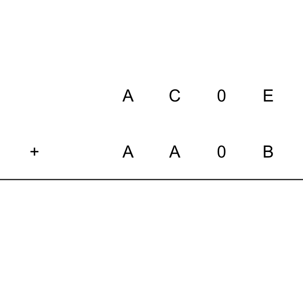

Then add each digit, starting at the right. Carry higher-power digits as needed. Sorry, I was not able to code how to show this step by step yet.

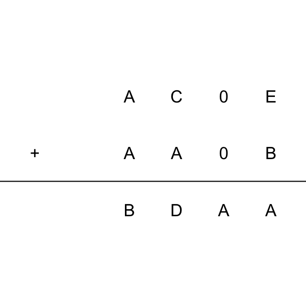

Use that table to add:

$$\text{ACCA0}+\text{AAC0A}$$

Line up the two numbers.

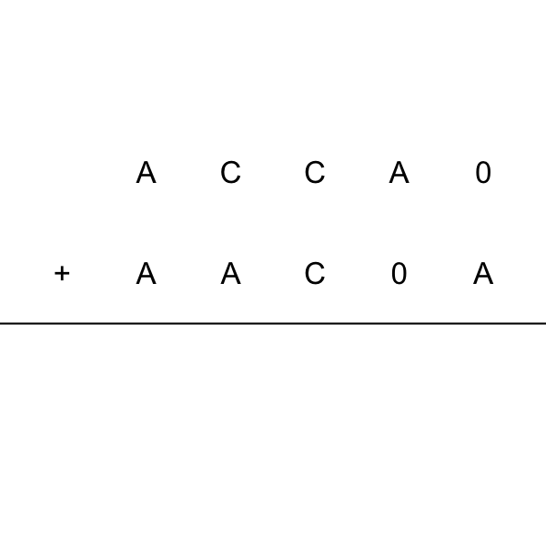

Then add each digit, starting at the right. Carry higher-power digits as needed. Sorry, I was not able to code how to show this step by step yet.

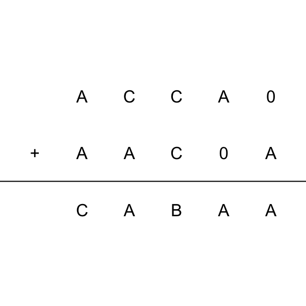

Use that table to add:

$$\text{F0A}+\text{ABAC}$$

Line up the two numbers.

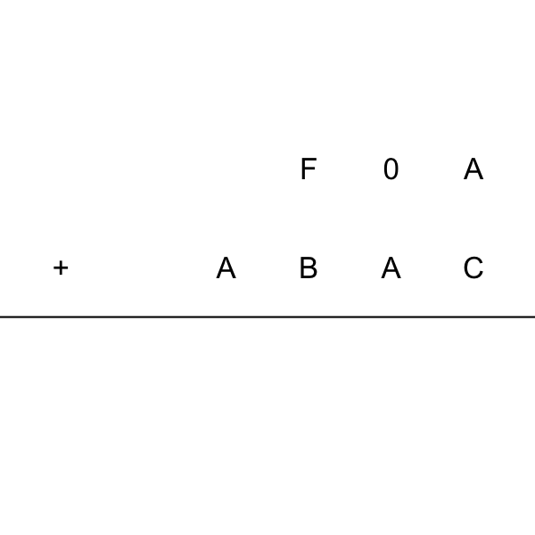

Then add each digit, starting at the right. Carry higher-power digits as needed. Sorry, I was not able to code how to show this step by step yet.

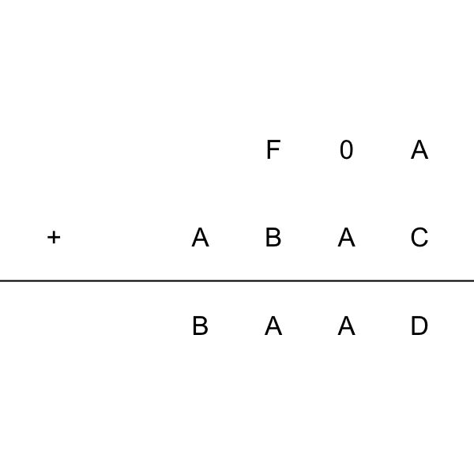

Use that table to add:

$$\text{BCAB}+\text{ADBA}$$

Line up the two numbers.

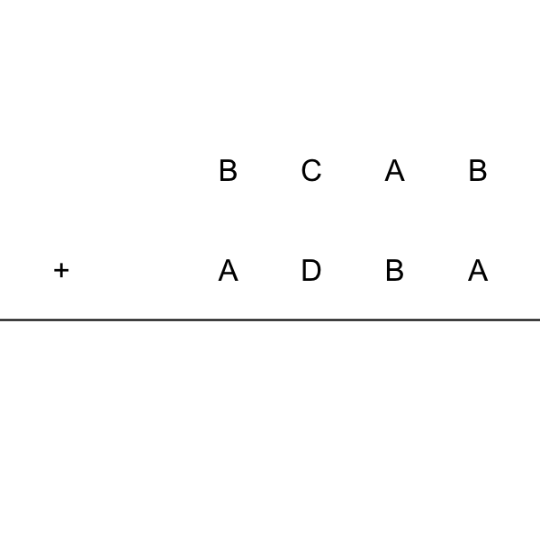

Then add each digit, starting at the right. Carry higher-power digits as needed. Sorry, I was not able to code how to show this step by step yet.

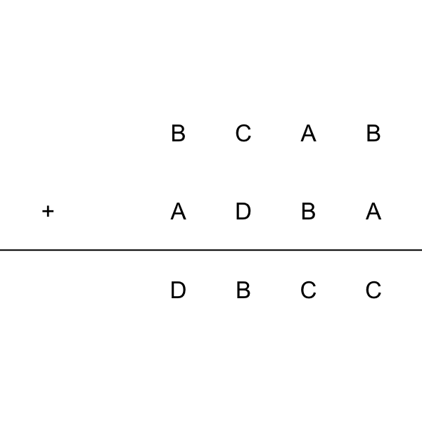

Use that table to add:

$$\text{ADBC}+\text{BD0B}$$

Line up the two numbers.

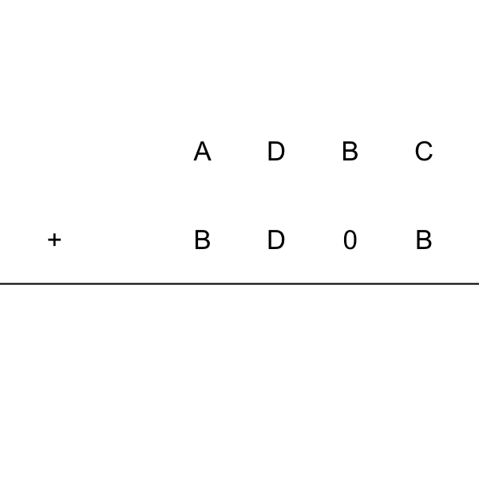

Then add each digit, starting at the right. Carry higher-power digits as needed. Sorry, I was not able to code how to show this step by step yet.

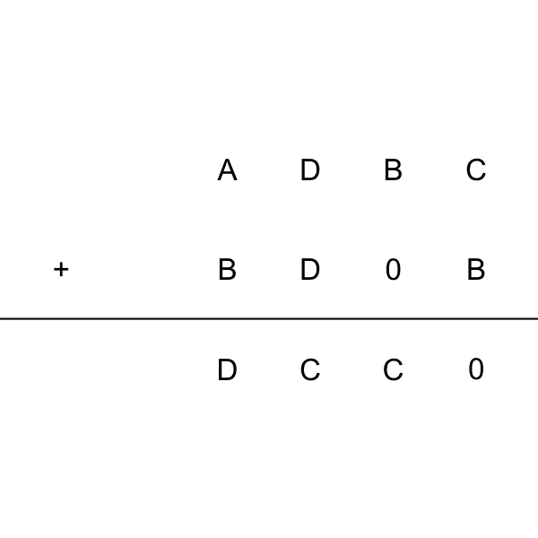

Use that table to add:

$$\text{B0CC}+\text{DDC}$$

Line up the two numbers.

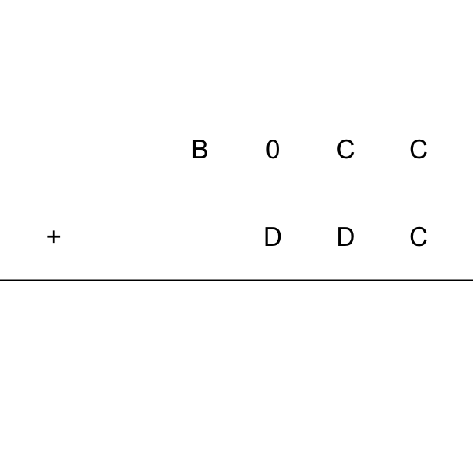

Then add each digit, starting at the right. Carry higher-power digits as needed. Sorry, I was not able to code how to show this step by step yet.

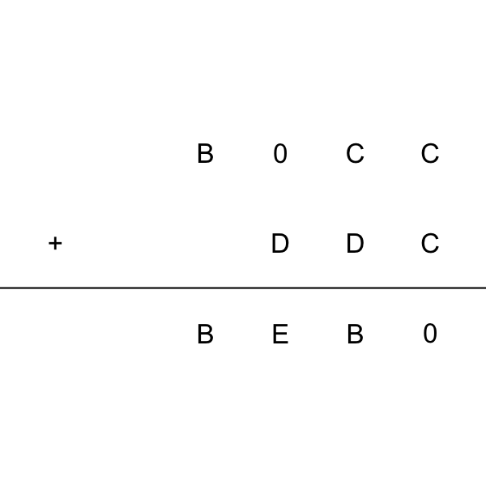

Use that table to add:

$$\text{A0DB}+\text{BADB}$$

Line up the two numbers.

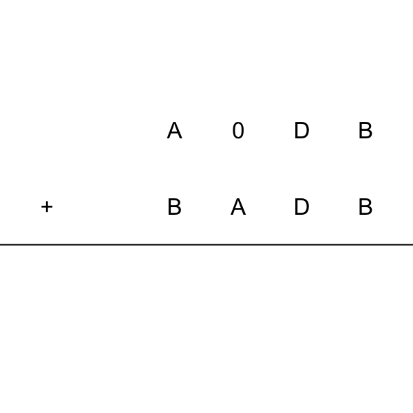

Then add each digit, starting at the right. Carry higher-power digits as needed. Sorry, I was not able to code how to show this step by step yet.

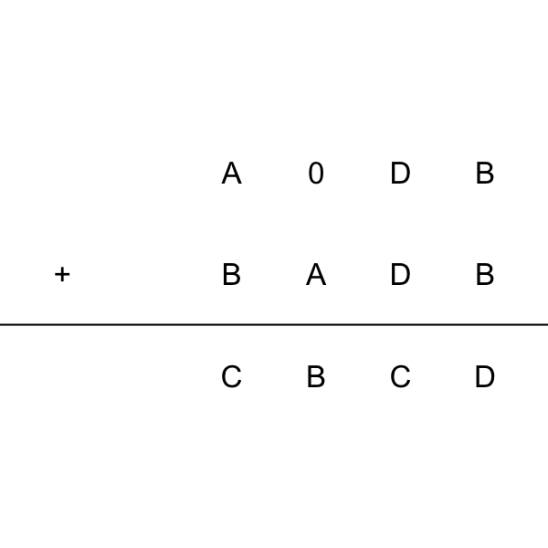

Use that table to add:

$$\text{DCC}+\text{FAF}$$

Line up the two numbers.

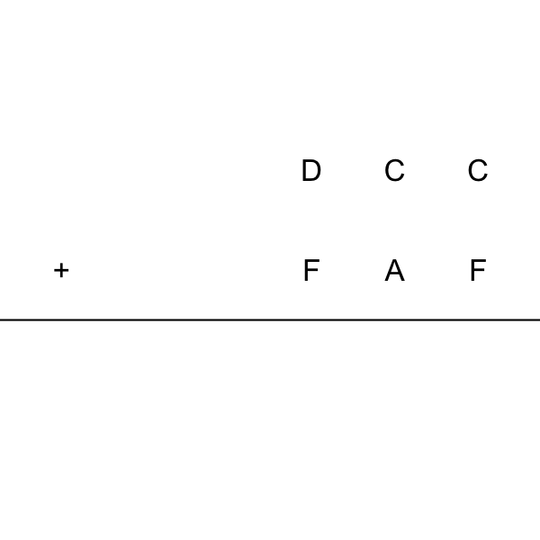

Then add each digit, starting at the right. Carry higher-power digits as needed. Sorry, I was not able to code how to show this step by step yet.

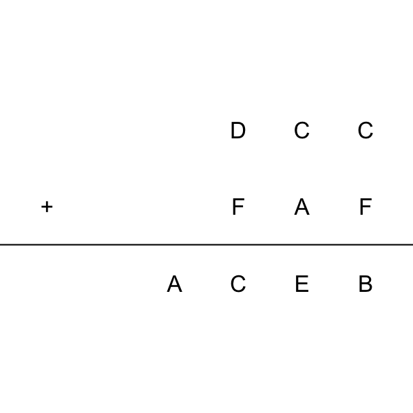

Use that table to add:

$$\text{F00}+\text{FGD}$$

Line up the two numbers.

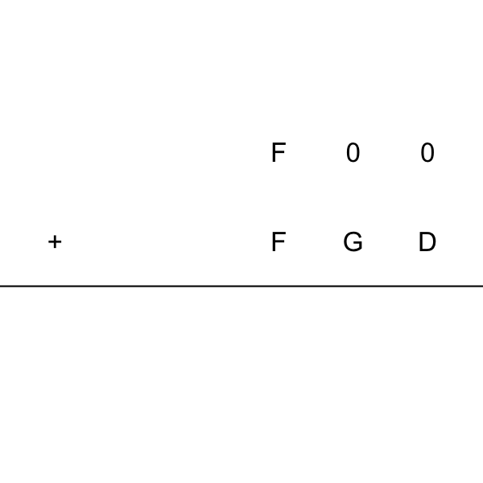

Then add each digit, starting at the right. Carry higher-power digits as needed. Sorry, I was not able to code how to show this step by step yet.

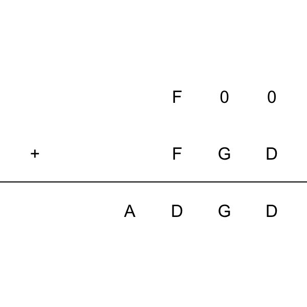

Use that table to add:

$$\text{BCB}+\text{FAA}$$

Line up the two numbers.

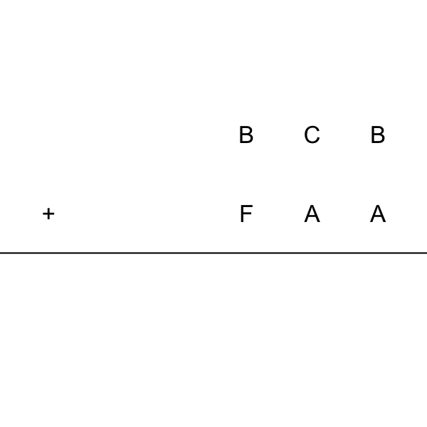

Then add each digit, starting at the right. Carry higher-power digits as needed. Sorry, I was not able to code how to show this step by step yet.

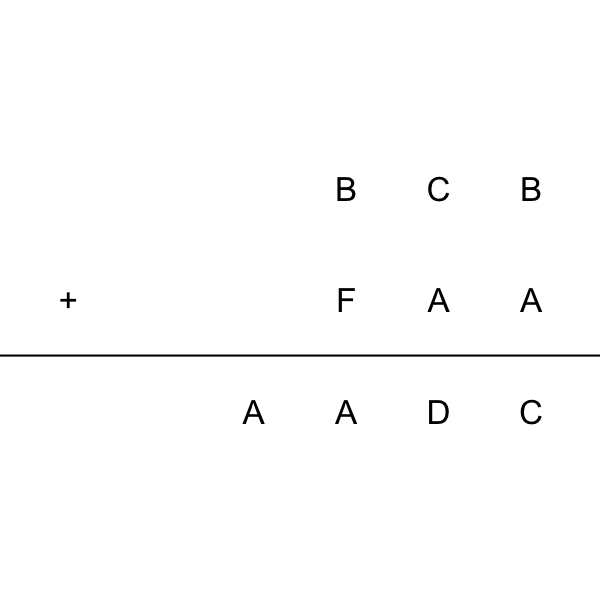

Use that table to add:

$$\text{ED0}+\text{ADBC}$$

Line up the two numbers.

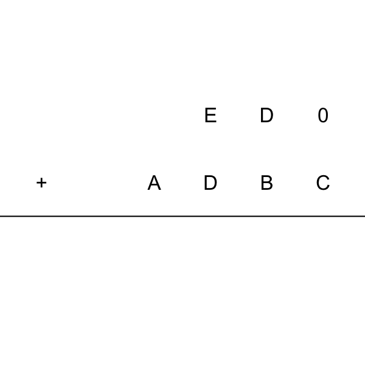

Then add each digit, starting at the right. Carry higher-power digits as needed. Sorry, I was not able to code how to show this step by step yet.

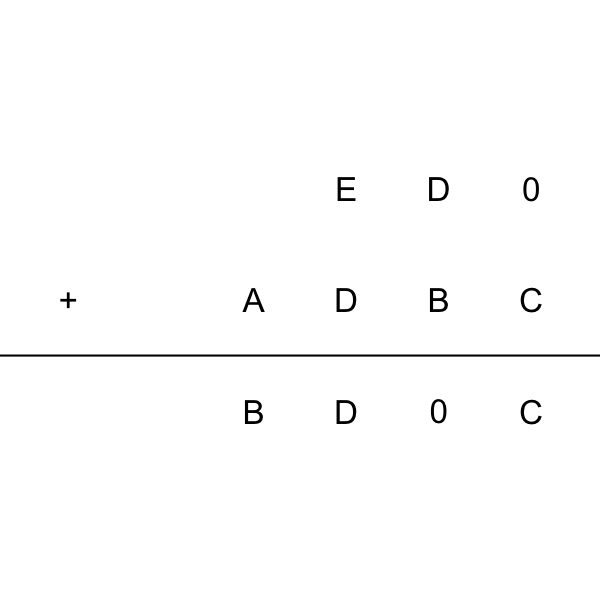

Use that table to add:

$$\text{CACC}+\text{ACBB}$$

Line up the two numbers.

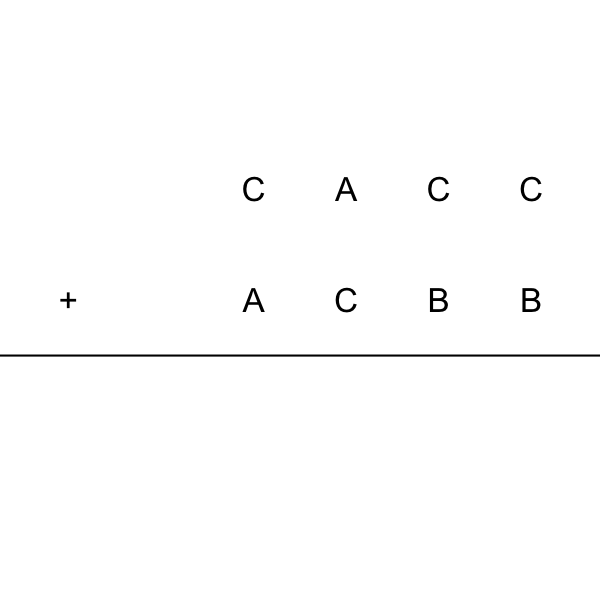

Then add each digit, starting at the right. Carry higher-power digits as needed. Sorry, I was not able to code how to show this step by step yet.

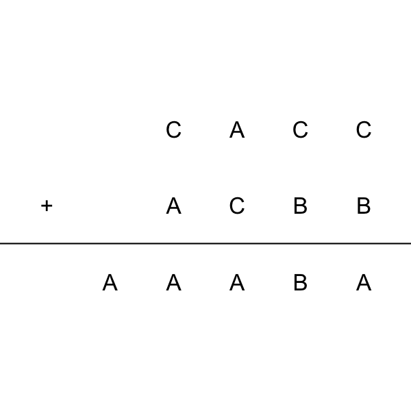

Use that table to add:

$$\text{EFA}+\text{DC0}$$

Line up the two numbers.

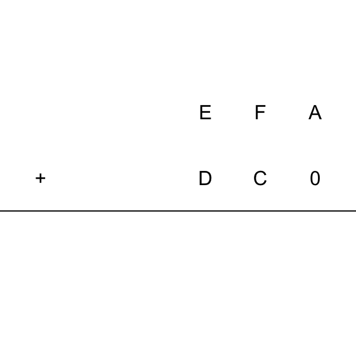

Then add each digit, starting at the right. Carry higher-power digits as needed. Sorry, I was not able to code how to show this step by step yet.

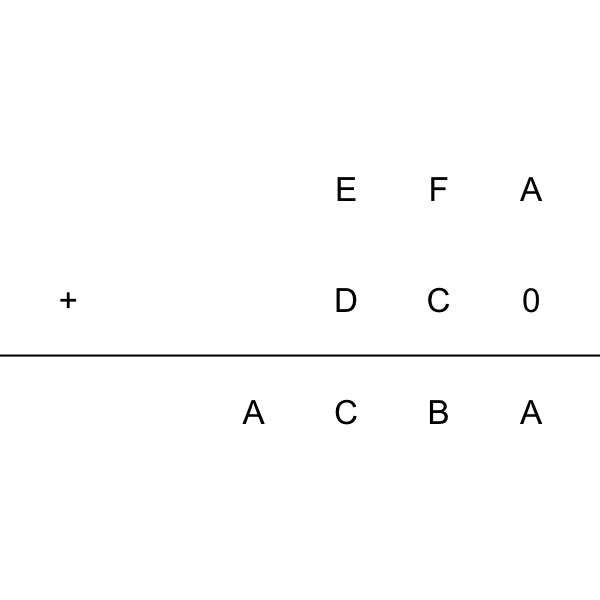

Use that table to add:

$$\text{FBF}+\text{CBC}$$

Line up the two numbers.

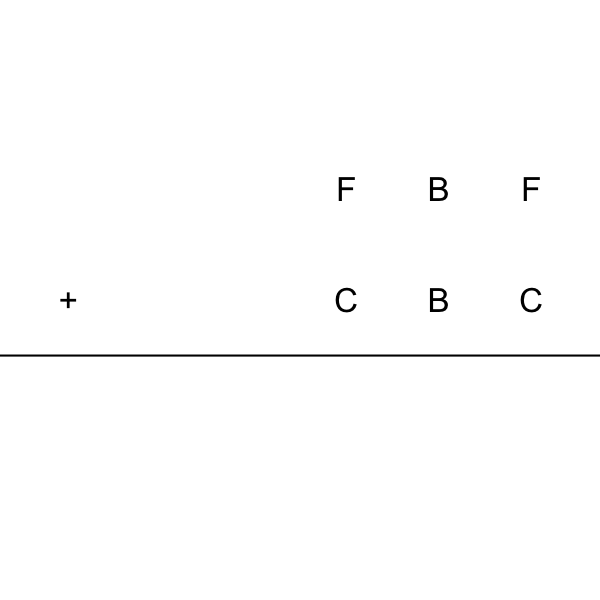

Then add each digit, starting at the right. Carry higher-power digits as needed. Sorry, I was not able to code how to show this step by step yet.

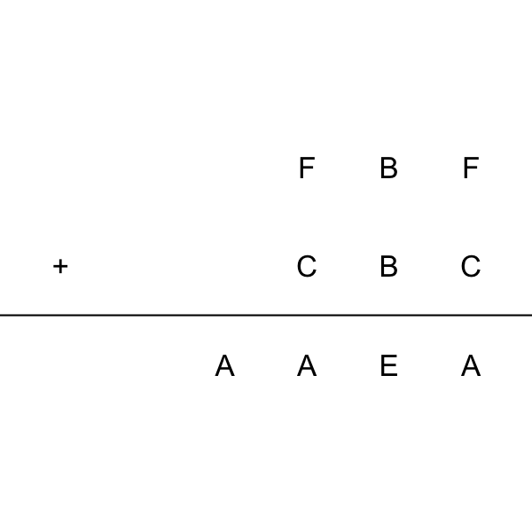

Use that table to add:

$$\text{BCBA}+\text{AACA0}$$

Line up the two numbers.

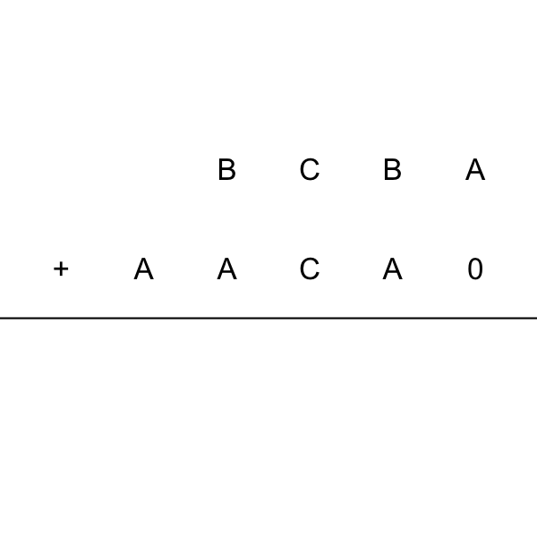

Then add each digit, starting at the right. Carry higher-power digits as needed. Sorry, I was not able to code how to show this step by step yet.

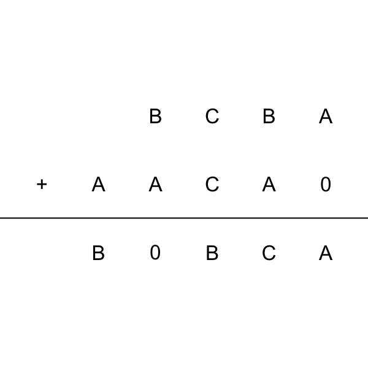

Use that table to add:

$$\text{FEF}+\text{ADG}$$

Line up the two numbers.

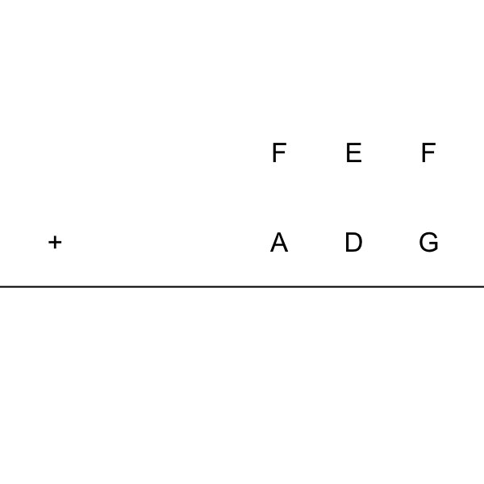

Then add each digit, starting at the right. Carry higher-power digits as needed. Sorry, I was not able to code how to show this step by step yet.

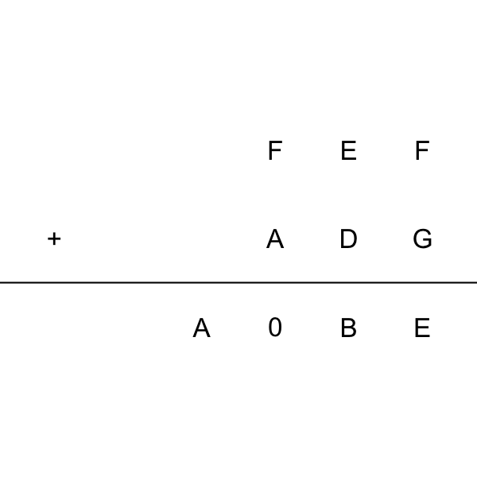

Use that table to add:

$$\text{AB0CC}+\text{ABAB}$$

Line up the two numbers.

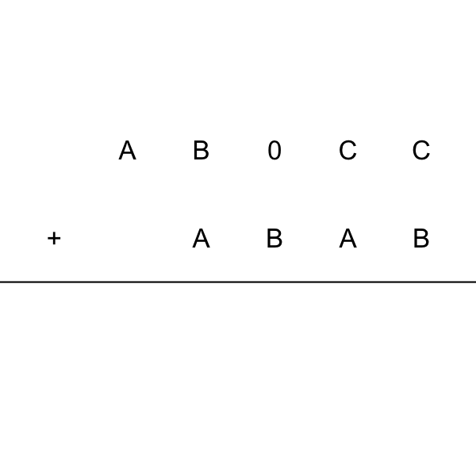

Then add each digit, starting at the right. Carry higher-power digits as needed. Sorry, I was not able to code how to show this step by step yet.

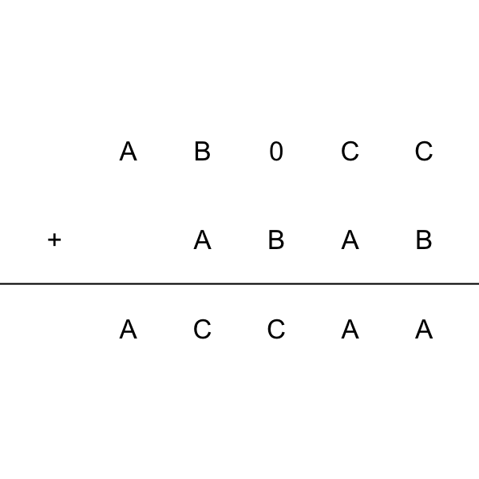

Use that table to add:

$$\text{DAC}+\text{BBDA}$$

Line up the two numbers.

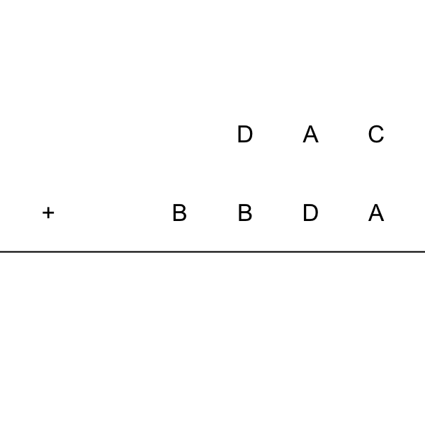

Then add each digit, starting at the right. Carry higher-power digits as needed. Sorry, I was not able to code how to show this step by step yet.

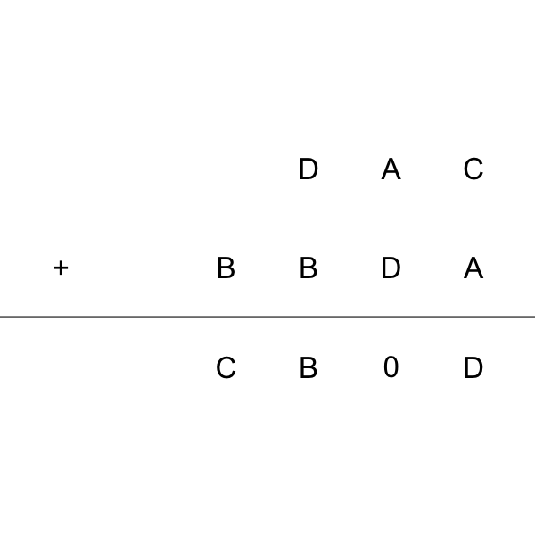

Use that table to add:

$$\text{ABAB0}+\text{ACBCB}$$

Line up the two numbers.

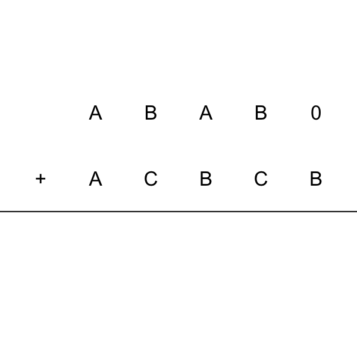

Then add each digit, starting at the right. Carry higher-power digits as needed. Sorry, I was not able to code how to show this step by step yet.

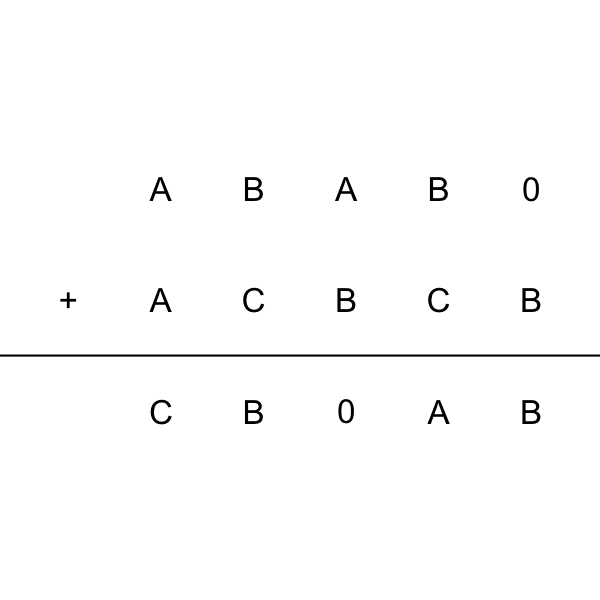

Use that table to add:

$$\text{DCG}+\text{FFA}$$

Line up the two numbers.

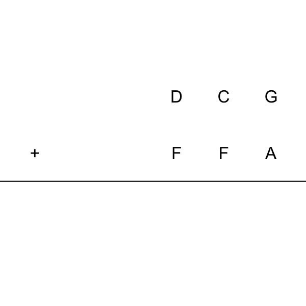

Then add each digit, starting at the right. Carry higher-power digits as needed. Sorry, I was not able to code how to show this step by step yet.

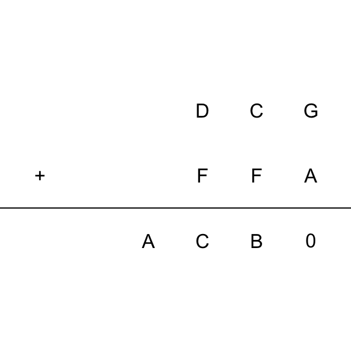